# Data Modeling

### 2. Survival Analysis

#### 2.1. Kaplan-Meier Survival Curve

```r
# Step 1: Convert date
boa_data$established_date <- mdy(boa_data$established_date)

# Step 2: Extract year from date
boa_data$established_year <- year(boa_data$established_date)

boa_data_filtered <- boa_data %>%
  filter(established_year < 2024) %>%
  mutate(
    entry_time = pmax(0, 2014 - established_year),
    exit_time  = 2024 - established_year,  # same as duration
    closed = as.numeric(as.character(closed))
  ) %>%
  filter(exit_time > entry_time)

boa_data_filtered <- boa_data_filtered %>%
  dplyr::select(closed,
                exit_time,
                combined_stat_area,
                deposits,
                branch_share,
                market_share,
                network_equity,
                deposit_change,
                nearby_boa_branches,
                total_nearby_competitor_branches,
                total_nearby_competitor_deposits,
                total_nearby_boa_deposits,
                estimate_household_median_income,
                estimate_household_mean_income,
                region_code,
                entry_time
                ) %>%
  filter(if_all(everything(), ~ !is.na(.) & !is.infinite(.)))
```

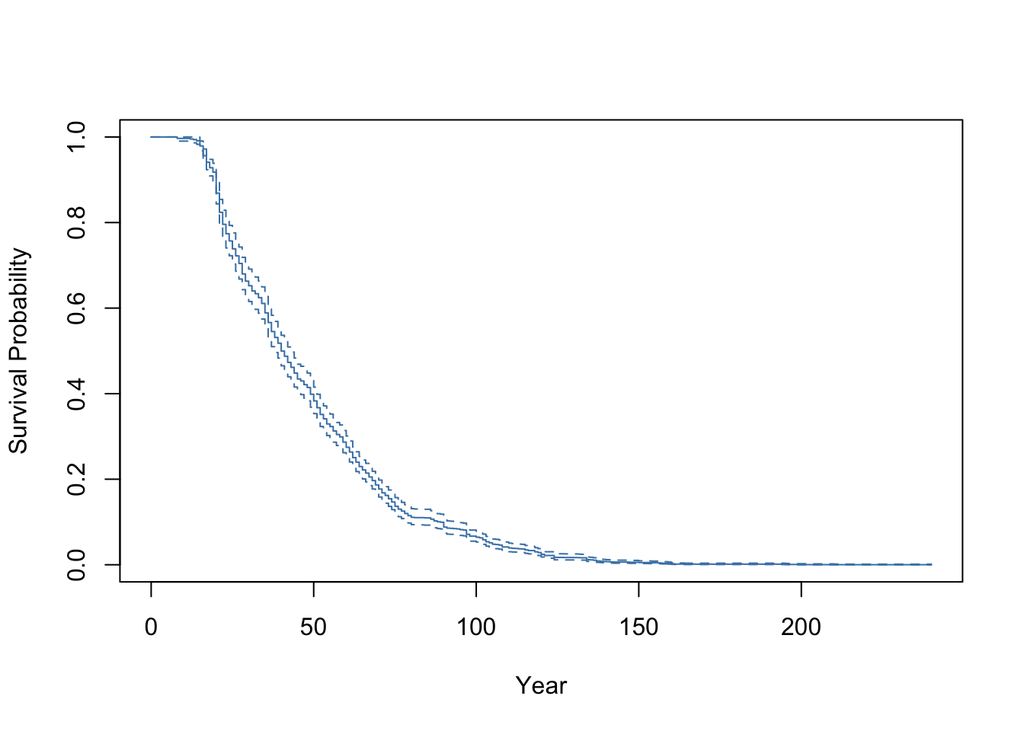

```r
surv_obj <- Surv(time = boa_data_filtered$entry_time,
                 time2 = boa_data_filtered$exit_time,
                 event = boa_data_filtered$closed)

# Kaplan-Meier
km_fit <- survfit(surv_obj ~ 1)

# Plot
plot(km_fit,
     xlab = "Year",
     ylab = "Survival Probability",
     col = "steelblue")
```

#### 2.2. Cox PH Model: Multiple Predictors

```r
surv_obj <- Surv(time = boa_data_filtered$entry_time,
                 time2 = boa_data_filtered$exit_time,
                 event = boa_data_filtered$closed)

# Fit Cox PH model with multiple predictors
cox_full <- coxph(surv_obj ~ deposits + deposit_change +
                    network_equity + estimate_household_median_income + region_code,
                  data = boa_data_filtered)

# Display the summary
summary(cox_full)
```

```
## Call:
## coxph(formula = surv_obj ~ deposits + deposit_change + network_equity +
##     estimate_household_median_income + region_code, data = boa_data_filtered)
##
##   n= 4975, number of events= 1334
##
##                                        coef  exp(coef)   se(coef)       z
## deposits                         -2.081e-07  1.000e+00  9.093e-08  -2.289
## deposit_change                    2.599e-02  1.026e+00  1.346e-02   1.930
## network_equity                   -7.953e-02  9.236e-01  3.324e-02  -2.393
## estimate_household_median_income -1.022e-05  1.000e+00  9.001e-07 -11.350
## region_code                      -4.936e-01  6.104e-01  4.542e-02 -10.867
##                                  Pr(>|z|)
## deposits                           0.0221 *
## deposit_change                     0.0536 .
## network_equity                     0.0167 *
## estimate_household_median_income   <2e-16 ***
## region_code                        <2e-16 ***
## ---
## Signif. codes:  0 '***' 0.001 '**' 0.01 '*' 0.05 '.' 0.1 ' ' 1
##
##                                  exp(coef) exp(-coef) lower .95 upper .95
## deposits                            1.0000     1.0000    1.0000    1.0000
## deposit_change                      1.0263     0.9743    0.9996    1.0538
## network_equity                      0.9236     1.0828    0.8653    0.9857
## estimate_household_median_income    1.0000     1.0000    1.0000    1.0000
## region_code                         0.6104     1.6382    0.5584    0.6673
##
## Concordance= 0.657  (se = 0.008 )
## Likelihood ratio test= 380.5  on 5 df,   p=<2e-16
## Wald test            = 402.8  on 5 df,   p=<2e-16
## Score (logrank) test = 451.7  on 5 df,   p=<2e-16
```

#### 2.3. Model Assumption Checking

```r
zph <- cox.zph(cox_full)
print(zph)
```

```
##                                   chisq df       p
## deposits                          55.44  1 9.6e-14
## deposit_change                   101.17  1 < 2e-16
## network_equity                     2.55  1    0.11
## estimate_household_median_income   1.84  1    0.17
## region_code                        2.00  1    0.16
## GLOBAL                           187.88  5 < 2e-16
```

Deposits and deposit_change violates the PH assumption as its effect may change over time. One way to handle that is by interacting deposits with a function of time (like log(t)):

```r
cox_time_interact <- coxph(
  Surv(entry_time, exit_time, closed) ~
    tt(deposits) + tt(deposit_change) +
    network_equity + estimate_household_median_income + region_code,
  data = boa_data_filtered,
  tt = function(x, t, ...) x * log(t)
)
summary(cox_time_interact)
```

```
## Call:
## coxph(formula = Surv(entry_time, exit_time, closed) ~ tt(deposits) +
##     tt(deposit_change) + network_equity + estimate_household_median_income +
##     region_code, data = boa_data_filtered, tt = function(x, t,
##     ...) x * log(t))
##
##   n= 4975, number of events= 1334
##
##                                        coef  exp(coef)   se(coef)       z
## tt(deposits)                     -2.521e-08  1.000e+00  1.375e-08  -1.834
## tt(deposit_change)                2.922e-03  1.003e+00  2.460e-03   1.188
## network_equity                   -8.156e-02  9.217e-01  3.326e-02  -2.452
## estimate_household_median_income -1.034e-05  1.000e+00  8.942e-07 -11.568
## region_code                      -5.010e-01  6.059e-01  4.523e-02 -11.075
##                                  Pr(>|z|)
## tt(deposits)                       0.0667 .
## tt(deposit_change)                 0.2349
## network_equity                     0.0142 *
## estimate_household_median_income   <2e-16 ***
## region_code                        <2e-16 ***
## ---
## Signif. codes:  0 '***' 0.001 '**' 0.01 '*' 0.05 '.' 0.1 ' ' 1
##
##                                  exp(coef) exp(-coef) lower .95 upper .95
## tt(deposits)                        1.0000     1.0000    1.0000    1.0000
## tt(deposit_change)                  1.0029     0.9971    0.9981    1.0078
## network_equity                      0.9217     1.0850    0.8635    0.9838
## estimate_household_median_income    1.0000     1.0000    1.0000    1.0000
## region_code                         0.6059     1.6503    0.5545    0.6621
##
## Concordance= 0.651  (se = 0.009 )
## Likelihood ratio test= 374.7  on 5 df,   p=<2e-16
## Wald test            = 388  on 5 df,   p=<2e-16
## Score (logrank) test = 451.5  on 5 df,   p=<2e-16
```

Before interpreting the results of the Cox Proportional Hazards Model, we examined its key assumptions.

To correct for this, we implemented a time-dependent Cox model using the tt() function, allowing deposit effects to vary with log-transformed time. This correction ensures our final model better captures the dynamic risk structure over a branch’s lifespan.

To validate our time-interaction Cox model, we conducted 5-fold cross-validation and computed the concordance index for each fold.

```r
folds <- createFolds(boa_data_filtered$closed, k = 5, list = TRUE)
c_indices <- numeric(length(folds))

for (i in seq_along(folds)) {
  train_idx <- setdiff(seq_len(nrow(boa_data_filtered)), folds[[i]])
  train_data <- boa_data_filtered[train_idx, ]
  test_data  <- boa_data_filtered[folds[[i]], ]

  # Fit time-dependent Cox model with left truncation
  model <- coxph(Surv(entry_time, exit_time, closed) ~
                   tt(deposits) + tt(deposit_change) +
                   network_equity + estimate_household_median_income + region_code,
                 data = train_data,
                 tt = function(x, t, ...) x * log(t))

  # Predict risk scores on test set
  pred <- predict(model, newdata = test_data, type = "lp")

  # Survival object for test set
  surv_test <- Surv(test_data$entry_time, test_data$exit_time, test_data$closed)

  # Concordance index
  c_indices[i] <- survConcordance(surv_test ~ pred)$concordance
}

# Report average C-index
mean_c_index <- mean(c_indices)
print(paste("Average C-index across folds:", round(mean_c_index, 4)))
```

```
## [1] "Average C-index across folds: 0.6514"
```